# After finishing the Data Wrangling process we will be able to :

- Store Data in .csv file (twitter_archive_master.csv)
- Analyze Data (Pandas Dataframe)
- Visualize Data.

WeRateDogs is a Twitter account that rates people's dogs with a humorous comment about the dog. These ratings almost always have a denominator of 10. The numerators however are almost always greater than 10 (11/10, 12/10, 13/10, .....). In theory the rates should be 1 to 10. However, WeRateDogs disagree, they admit almost all dogs deserve a 10 and sometimes more than that.

That rating gives us a closer look to see which dog type (breed) is most common dog in the tweet dataset, What dog type has the highest average rating, And that the dog types with low number of ratings show a high variaty of mean ratings.

The most rated dog was golden retriever with more than 140 ratings

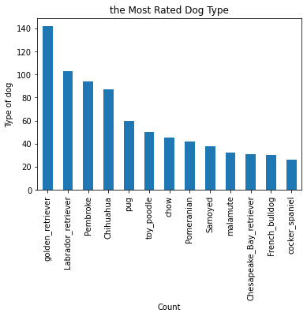

The blue dot on the very right represents the approximately 140 ratings of golden retriever. On average these ratings are high 11.59. This really shows that the golden retriever is very popular.

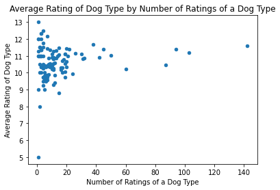

Many tweets have been retweeted more than 1000 times some more than even 50000 times.

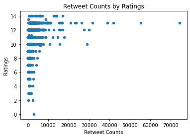